# Product Pricing Algorithm

Alexei Domorev

2023-02-23

## Problem Statement

Research and Development wants help to determine new product ideas and pricing using existing product line as a benchmark.

## Solution Summary

We’ve identified several product gaps in the existing product line including:

1. Aluminum Over Mountain
2. Aluminum Triathlon

The Data Science team has developed a pricing model that uses predictive analytics to estimate the price of the new bicycle models based on the existing fleet. This ensures that new models are priced comparatively o other similar bicycles.

New product prediction for two new models:

1. Trigger, Over Mountain with Aluminum Frame: $3,265
2. Slice, Triathlon with Aluminum Frame: $2, 677

**Next Steps:** Integrate the model into a proof-of-concept web application that can be deployed to the R&D Department.

## Gap Analysis

### Bike List

Our current product portfolio consists of 97 bike models that were analysed.

| id | price | model | category_1 | category_2 | frame_material | model_base | model_tier | black | hi_mod | team | red | ultegra | dura_ace | disc |
| --- | --- | --- | --- | --- | --- | --- | --- | --- | --- | --- | --- | --- | --- | --- |
| 1 | 6070 | Jekyll Carbon 2 | Mountain | Over Mountain | Carbon | Jekyll | Carbon 2 | 0 | 0 | 0 | 0 | 0 | 0 | 0 |
| 2 | 5970 | Trigger Carbon 2 | Mountain | Over Mountain | Carbon | Trigger | Carbon 2 | 0 | 0 | 0 | 0 | 0 | 0 | 0 |
| 3 | 2770 | Beast of the East 1 | Mountain | Trail | Aluminum | Beast of the East | 1 | 0 | 0 | 0 | 0 | 0 | 0 | 0 |
| 4 | 10660 | Supersix Evo Hi-Mod Team | Road | Elite Road | Carbon | Supersix Evo | Hi-Mod Team | 0 | 1 | 1 | 0 | 0 | 0 | 0 |
| 5 | 3200 | Jekyll Carbon 4 | Mountain | Over Mountain | Carbon | Jekyll | Carbon 4 | 0 | 0 | 0 | 0 | 0 | 0 | 0 |
| 6 | 12790 | Supersix Evo Black Inc. | Road | Elite Road | Carbon | Supersix Evo | Black Inc. | 1 | 0 | 0 | 0 | 0 | 0 | 0 |
| 7 | 5330 | Supersix Evo Hi-Mod Dura Ace 2 | Road | Elite Road | Carbon | Supersix Evo | Hi-Mod Dura Ace 2 | 0 | 1 | 0 | 0 | 0 | 1 | 0 |
| 8 | 1570 | Synapse Disc 105 | Road | Endurance Road | Aluminum | Synapse | Disc 105 | 0 | 0 | 0 | 0 | 0 | 0 | 1 |
| 9 | 4800 | Synapse Carbon Disc Ultegra D12 | Road | Endurance Road | Carbon | Synapse | Carbon Disc Ultegra D12 | 0 | 0 | 0 | 0 | 1 | 0 | 1 |
| 10 | 480 | Catalyst 3 | Mountain | Sport | Aluminum | Catalyst | 3 | 0 | 0 | 0 | 0 | 0 | 0 | 0 |

[output cut: 87 more lines]

### Gaps

The visualisation segments the full bicycle product line by category and frame material. This exposes two product gaps or opportunities for new products:

1. New **Aluminum** line of bikes in the **Over Mountain** category
2. New **Aluminum** line of bikes in the **Triathlon** category

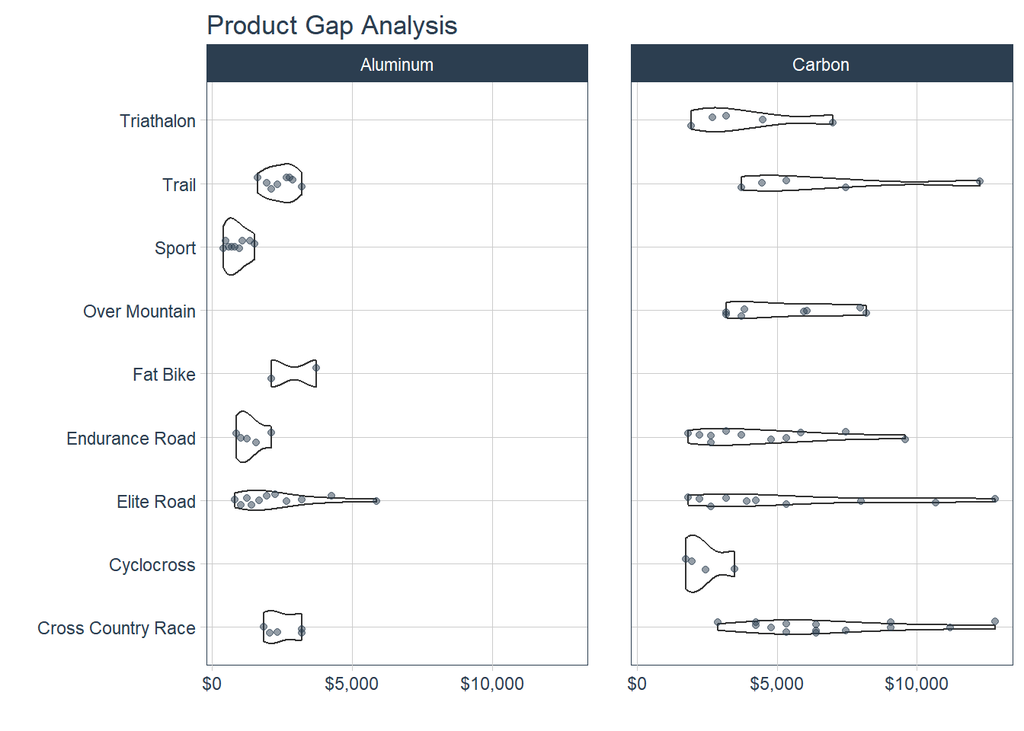

## Price Prediction

New product prediction for the two new models:

1. Trigger, Over Mountain with Aluminum Frame: $3,265;
2. Slice, Triathlon with Aluminum Frame: $2, 677.

Price Prediction

[output not shown]